# Iris - Classification Using Nearest Neighbors

##### **Requirement** : Create a clasification Model that can identify Species on the basis of Sepal and Petal size.

##### **Solution** : There are 150 observations, Model will use 80% records to train the model and remaining 20% data will be used to test its performance.

#### Import Observation Data

```r
iris <- read.csv("iris.csv")
head(iris)
```

|  | Id | SepalLengthCm | SepalWidthCm | PetalLengthCm | PetalWidthCm | Species |
| --- | --- | --- | --- | --- | --- | --- |
| 1 | 1 | 5.1 | 3.5 | 1.4 | 0.2 | Iris-setosa |
| 2 | 2 | 4.9 | 3.0 | 1.4 | 0.2 | Iris-setosa |
| 3 | 3 | 4.7 | 3.2 | 1.3 | 0.2 | Iris-setosa |
| 4 | 4 | 4.6 | 3.1 | 1.5 | 0.2 | Iris-setosa |
| 5 | 5 | 5.0 | 3.6 | 1.4 | 0.2 | Iris-setosa |
| 6 | 6 | 5.4 | 3.9 | 1.7 | 0.4 | Iris-setosa |

#### Exploratory Data Analysis

```r
str(iris)
```

```
'data.frame':   150 obs. of  6 variables:
 $ Id           : int  1 2 3 4 5 6 7 8 9 10 ...
 $ SepalLengthCm: num  5.1 4.9 4.7 4.6 5 5.4 4.6 5 4.4 4.9 ...
 $ SepalWidthCm : num  3.5 3 3.2 3.1 3.6 3.9 3.4 3.4 2.9 3.1 ...
 $ PetalLengthCm: num  1.4 1.4 1.3 1.5 1.4 1.7 1.4 1.5 1.4 1.5 ...
 $ PetalWidthCm : num  0.2 0.2 0.2 0.2 0.2 0.4 0.3 0.2 0.2 0.1 ...
 $ Species      : Factor w/ 3 levels "Iris-setosa",..: 1 1 1 1 1 1 1 1 1 1 ...
```

```r
summary(iris)
```

```
       Id         SepalLengthCm    SepalWidthCm   PetalLengthCm    PetalWidthCm              Species
 Min.   :  1.00   Min.   :4.300   Min.   :2.000   Min.   :1.000   Min.   :0.100   Iris-setosa    :50
 1st Qu.: 38.25   1st Qu.:5.100   1st Qu.:2.800   1st Qu.:1.600   1st Qu.:0.300   Iris-versicolor:50
 Median : 75.50   Median :5.800   Median :3.000   Median :4.350   Median :1.300   Iris-virginica :50
 Mean   : 75.50   Mean   :5.843   Mean   :3.054   Mean   :3.759   Mean   :1.199
 3rd Qu.:112.75   3rd Qu.:6.400   3rd Qu.:3.300   3rd Qu.:5.100   3rd Qu.:1.800
 Max.   :150.00   Max.   :7.900   Max.   :4.400   Max.   :6.900   Max.   :2.500
```

*Data is very much balance. There are 50 observations for each species. It does not contain any missing value. Summary is also not telling about extreame outliers*

Lets understand the data distribution and relation between width and length

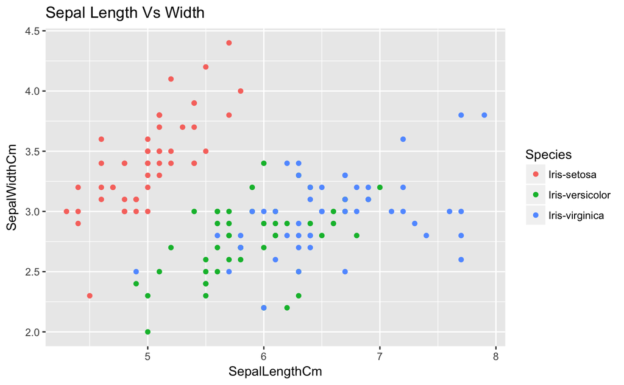

```r
suppressWarnings(suppressMessages(library(ggplot2)))
ggplot( data = iris, aes(x = SepalLengthCm,y = SepalWidthCm))  +
  geom_point(aes(color= Species)) +
  ggtitle("Sepal Length Vs Width")
```

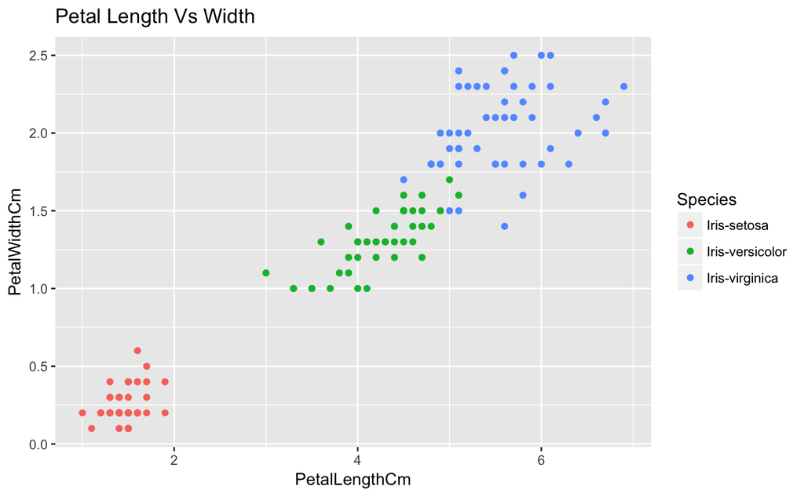

```r
ggplot( data = iris, aes(x = PetalLengthCm, y = PetalWidthCm))  +
  geom_point(aes(color= Species)) +
  ggtitle("Petal Length Vs Width")
```

*Sepal plot shows that Setosa is linear separable but rest Soecies are not linear separable. Petal data clealy dividing data and they can be linearly separable. Only few observation of Virginica are mixing with Versicolor.*

##### Function to tranform data to standard range by using z-score standardization

```r
PreProcessing <- function(data,parameter=NULL){
  label_names <- colnames(data)
  len <- length(label_names)
  data_standardized <- cbind(data.frame(scale(data[,-len])),Species = data[,len])
  return(data_standardized)
}
```

##### Function to divide data into training and validation sets

```r
SplitData <- function(data,train_percent,train="Y"){
  library(caTools)
  set.seed(2017)
  len <- length(colnames(data()))
  ratio = train_percent/100
  split = sample.split(data$Species, SplitRatio = ratio)
  train.set <- subset(data, split == TRUE)
  valid.set <- subset(data, split == FALSE)
  if (train == 'Y'){
    return(train.set)
  } else {
    return(valid.set)
  }
}
```

##### Function to Build Model and Predict

*This function accepts training and validation set of data and returns crosstable comparision between actual and predicted value*

```r
library(class)
library(gmodels)
build_and_predict <- function(train.data,test.data,k){
  set.seed(2017)
  len <- length(colnames(train.data))
  class_Label <- train.data[,len]
  pred <- knn(train.data[-len],test.data[-len],cl = class_Label , k = k)
  valid_label <- test.data[,len]
  m <- CrossTable(test.data[,len],pred,prop.chisq = FALSE)
  return(m)
}
```

##### Function to calculate the percentage of correctly classified observation

```r
eff <- function(xtable,test.data){
  dummy <- data.frame(xtable$t)
  obs <- nrow(test.data)
  matched_count <- sum(ifelse(dummy$x ==dummy$y,dummy$Freq,0))
  efficiency <- round(matched_count * 100/obs,2)
}
```

### Complete Processing

```r
# standarized the data
iris.scale <- PreProcessing(iris[,-1])
# Split data in training and validation set
iris.scale.train <- SplitData(iris.scale,80,"Y")
iris.scale.test <- SplitData(iris.scale,80,"N")
```

**Model Efficiency for different K value**

```r
model.eff
```

|  | K | eff |
| --- | --- | --- |
| 1 | 1 | 93.33 |
| 2 | 6 | 96.67 |

#### Get crossTable for all K value

```r
for ( k in model.eff$K){
  m <- build_and_predict(iris.scale.train,iris.scale.test,k)
  print(paste0("Efficieny for K = ",k, " is ",eff(m,iris.scale.test)))
}
```

```
   Cell Contents
|-------------------------|
|                       N |
|           N / Row Total |
|           N / Col Total |
|         N / Table Total |
|-------------------------|


Total Observations in Table:  30


                 | pred
test.data[, len] |     Iris-setosa | Iris-versicolor |  Iris-virginica |       Row Total |
-----------------|-----------------|-----------------|-----------------|-----------------|
     Iris-setosa |              10 |               0 |               0 |              10 |
                 |           1.000 |           0.000 |           0.000 |           0.333 |
                 |           1.000 |           0.000 |           0.000 |                 |
                 |           0.333 |           0.000 |           0.000 |                 |
-----------------|-----------------|-----------------|-----------------|-----------------|
 Iris-versicolor |               0 |               8 |               2 |              10 |
                 |           0.000 |           0.800 |           0.200 |           0.333 |
                 |           0.000 |           1.000 |           0.167 |                 |
                 |           0.000 |           0.267 |           0.067 |                 |
-----------------|-----------------|-----------------|-----------------|-----------------|
  Iris-virginica |               0 |               0 |              10 |              10 |
                 |           0.000 |           0.000 |           1.000 |           0.333 |
                 |           0.000 |           0.000 |           0.833 |                 |
                 |           0.000 |           0.000 |           0.333 |                 |
-----------------|-----------------|-----------------|-----------------|-----------------|
    Column Total |              10 |               8 |              12 |              30 |
                 |           0.333 |           0.267 |           0.400 |                 |
-----------------|-----------------|-----------------|-----------------|-----------------|


[1] "Efficieny for K = 1 is 93.33"


   Cell Contents
|-------------------------|
```

[output cut: 19 more lines]

```
                 |           0.000 |           0.900 |           0.100 |           0.333 |
                 |           0.000 |           1.000 |           0.091 |                 |
                 |           0.000 |           0.300 |           0.033 |                 |
-----------------|-----------------|-----------------|-----------------|-----------------|
  Iris-virginica |               0 |               0 |              10 |              10 |
                 |           0.000 |           0.000 |           1.000 |           0.333 |
                 |           0.000 |           0.000 |           0.909 |                 |
                 |           0.000 |           0.000 |           0.333 |                 |
-----------------|-----------------|-----------------|-----------------|-----------------|
    Column Total |              10 |               9 |              11 |              30 |
                 |           0.333 |           0.300 |           0.367 |                 |
-----------------|-----------------|-----------------|-----------------|-----------------|


[1] "Efficieny for K = 6 is 96.67"
```